# Tidybiology Final Project

Claudia Wong

November 04, 2022

## Load libraries

The libraries I loaded were tidyverse and medicaldata. The [medicaldata package](https://github.com/higgi13425/medicaldata) can be found on Github and it contains medical data sets for teaching reproducible medical research with R.

I then looked at the data sets to decide which to use.

```
##  [1] "blood_storage"   "covid_testing"   "cytomegalovirus" "esoph_ca"
##  [5] "indo_rct"        "indometh"        "laryngoscope"    "licorice_gargle"
##  [9] "opt"             "polyps"          "scurvy"          "smartpill"
## [13] "strep_tb"        "supraclavicular" "theoph"
```

## Import Data

The Licorice Gargle study tested if gargling with licorice solution immediately before anesthesia prevents sore throat and postextubation coughing in patients that were intubated with double-lumen tubes.

The study is Ruetzler et al. “[A Randomized, Double-Blind Comparison of Licorice Versus Sugar-Water Gargle for Prevention of Postoperative Sore Throat and Postextubation Coughing](https://journals.lww.com/anesthesia-analgesia/Fulltext/2013/09000/A_Randomized,_Double_Blind_Comparison_of_Licorice.12.aspx)”. *Anesth Analg.* 2013; 117: 614 - 21.

Reason for study: a previous study reported that gargling with licorice halves the risk of sore throat after intubation with conventional endotracheal tubes.

## Glimpse Data

This data set has **235 observations** and **19 variables**.

The variables are gender, physical status, BMI, age, Mallampati score, smoking status, preoperative pain, surgery size, intervention and the outcomes (cough, sore throat and pain swallowing at various time points).

```
## Rows: 235
## Columns: 19
## $ preOp_gender           <dbl> 0, 0, 0, 0, 0, 0, 0, 0, 0, 0, 0, 0, 0, 0, 0, 0,…
## $ preOp_asa              <dbl> 3, 2, 2, 2, 1, 2, 3, 2, 3, 3, 2, 2, 2, 2, 3, 2,…
## $ preOp_calcBMI          <dbl> 32.98, 23.66, 26.83, 28.39, 30.45, 35.49, 25.50…
## $ preOp_age              <dbl> 67, 76, 58, 59, 73, 61, 66, 61, 83, 69, 31, 72,…
## $ preOp_mallampati       <dbl> 2, 2, 2, 2, 1, 3, 1, 2, 1, 2, 1, 2, 2, 1, 2, 2,…
## $ preOp_smoking          <dbl> 1, 2, 1, 1, 2, 1, 1, 1, 1, 3, 1, 2, 3, 3, 3, 1,…
## $ preOp_pain             <dbl> 0, 0, 0, 0, 0, 0, 0, 0, 0, 0, 0, 0, 0, 0, 0, 0,…
## $ treat                  <dbl> 1, 1, 1, 1, 1, 1, 1, 1, 1, 1, 1, 1, 1, 1, 1, 1,…
## $ intraOp_surgerySize    <dbl> 2, 1, 2, 3, 2, 3, 3, 1, 1, 2, 2, 1, 1, 2, 2, 2,…
## $ extubation_cough       <dbl> 0, 0, 0, 0, 0, 0, 0, 0, 0, 0, 0, 0, 0, 0, 0, 0,…
## $ pacu30min_cough        <dbl> 0, 0, 0, 0, 0, 0, 0, 0, 0, 0, 0, 0, 0, 0, 0, 0,…
## $ pacu30min_throatPain   <dbl> 0, 0, 0, 0, 0, 0, 0, 0, 0, 0, 0, 0, 0, 0, 0, 0,…
## $ pacu30min_swallowPain  <dbl> 0, 0, 0, 0, 0, 0, 0, 0, 0, 0, 0, 0, 0, 0, 0, 0,…
## $ pacu90min_cough        <dbl> 0, 0, 0, 0, 0, 0, 0, 0, 0, 0, 0, 0, 0, 0, 0, 0,…
## $ pacu90min_throatPain   <dbl> 0, 0, 0, 0, 0, 0, 0, 0, 0, 0, 0, 0, 0, 0, 0, 0,…
## $ postOp4hour_cough      <dbl> 0, 0, 0, 0, 0, 0, 0, 0, 0, 0, 0, 0, 0, 0, 0, 0,…
## $ postOp4hour_throatPain <dbl> 0, 0, 0, 0, 0, 0, 0, 0, 0, 0, 0, 0, 0, 0, 0, 0,…
## $ pod1am_cough           <dbl> 0, 0, 0, 0, 0, 0, 0, 0, 0, 0, 0, 0, 0, 0, 0, 0,…
## $ pod1am_throatPain      <dbl> 0, 0, 0, 0, 0, 0, 0, 0, 0, 0, 0, 0, 0, 0, 0, 0,…
```

## EDA

#### Exploratory Data Analysis

I chose to examine levels of throat pain over time in treated and non-treated groups. I struggled with having columns be the variable on the x-axis, but fixed it. I could not fix the treatment level to be only dark and light blue.

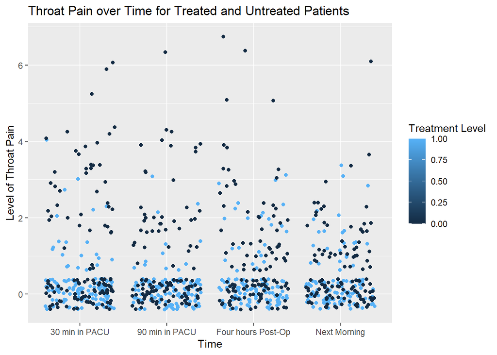

## Failure?

I tried to use box plots to quantify the data above, but the results for treated patients may be wrong.

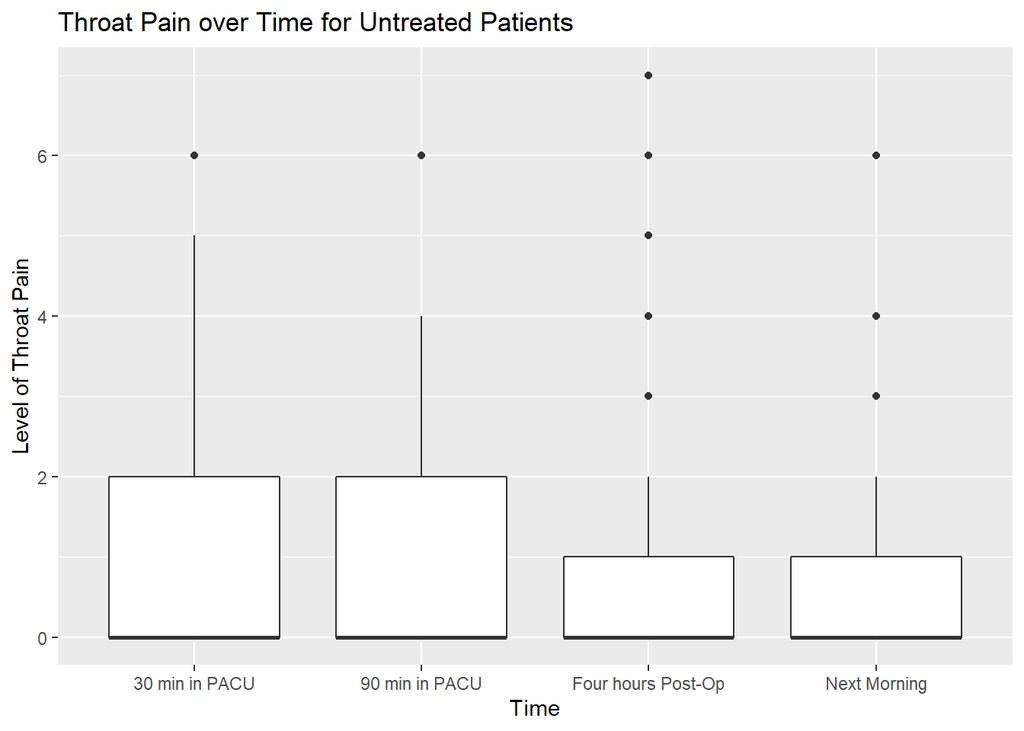

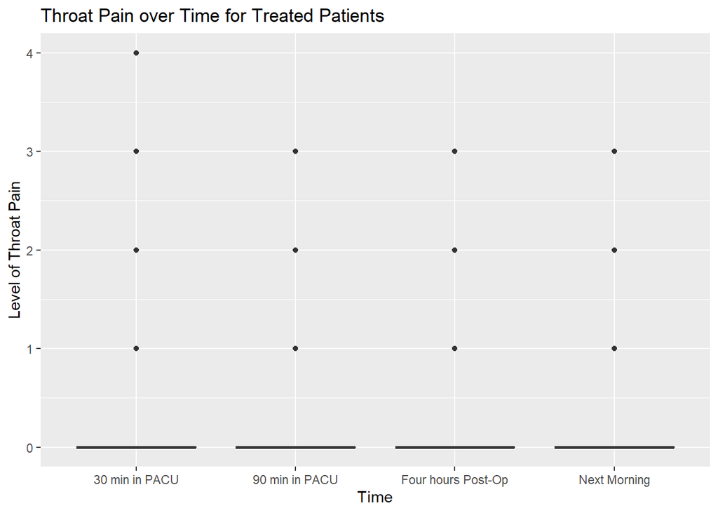

## Final Graph

I attempted to make a grouped bar chart to show the mean of each condition, but I could not get rid of the error: *Warning: argument is not numeric or logical: returning NA*.

`num_licgar = licorice_gargle %>%` `filter(pacu30min_throatPain >= 0, pacu90min_throatPain >= 0,` `postOp4hour_throatPain >= 0, pod1am_throatPain >= 0)`

`time <- c(rep("30 min in PACU", 2), rep("90 min in PACU", 2),` `rep("Four hours Post-Op", 2), rep("Next Morning", 2) )`

`treatment <- rep(c("Treated" , "Untreated"), 4)`

`avg_throat_pain <- c(mean(num_licgar, pacu30min_throatPain),` `mean(num_licgar, pacu90min_throatPain), mean(num_licgar,` `postOp4hour_throatPain), mean(num_licgar, pod1am_throatPain))`

`data <- data.frame(time, treatment, avg_throat_pain)`

## Prioritized follow-up studies

I would love if my code could work. Next I would look at cough severity over time in the 2 treatment groups. Then I would look at how other factors affect throat pain and cough severity, such as BMI and age.

## Acknowledgements

I would like to acknowledge medicaldata package and Akshay Bareja for recomminding I use it.